# Bayesian Neural Networks

In this tutorial, we demonstrate how one can implement a Bayesian Neural Network using a combination of Turing and [Flux](https://github.com/FluxML/Flux.jl), a suite of machine learning tools. We will use Flux to specify the neural network’s layers and Turing to implement the probabilistic inference, with the goal of implementing a classification algorithm.

We will begin with importing the relevant libraries.

```julia
using Turing
using FillArrays
using Flux
using Plots
using ReverseDiff

using LinearAlgebra
using Random
```

Our goal here is to use a Bayesian neural network to classify points in an artificial dataset. The code below generates data points arranged in a box-like pattern and displays a graph of the dataset we will be working with.

```julia
# Number of points to generate.
N = 80
M = round(Int, N / 4)
Random.seed!(1234)

# Generate artificial data.
x1s = rand(M) * 4.5;
x2s = rand(M) * 4.5;
xt1s = Array([[x1s[i] + 0.5; x2s[i] + 0.5] for i in 1:M])
x1s = rand(M) * 4.5;
x2s = rand(M) * 4.5;
append!(xt1s, Array([[x1s[i] - 5; x2s[i] - 5] for i in 1:M]))

x1s = rand(M) * 4.5;
x2s = rand(M) * 4.5;
xt0s = Array([[x1s[i] + 0.5; x2s[i] - 5] for i in 1:M])
x1s = rand(M) * 4.5;
x2s = rand(M) * 4.5;
append!(xt0s, Array([[x1s[i] - 5; x2s[i] + 0.5] for i in 1:M]))

# Store all the data for later.
xs = [xt1s; xt0s]
ts = [ones(2 * M); zeros(2 * M)]

# Convert xs to Float32
xs = hcat(xs...)
xs = convert(Array{Float32}, xs)

# Plot data points.
function plot_data()
    x1 = map(e -> e[1], xt1s)
    y1 = map(e -> e[2], xt1s)
    x2 = map(e -> e[1], xt0s)
    y2 = map(e -> e[2], xt0s)

    Plots.scatter(x1, y1; color="red", clim=(0, 1))
    return Plots.scatter!(x2, y2; color="blue", clim=(0, 1))
end

plot_data()
```

[figure not shown]

## Building a Neural Network

The next step is to define a [feedforward neural network](https://en.wikipedia.org/wiki/Feedforward_neural_network) where we express our parameters as distributions, and not single points as with traditional neural networks. For this we will use `Dense` to define liner layers and compose them via `Chain`, both are neural network primitives from Flux. The network `nn_initial` we created has two hidden layers with `tanh` activations and one output layer with sigmoid (`σ`) activation, as shown below.

[figure not shown]

The `nn_initial` is an instance that acts as a function and can take data as inputs and output predictions. We will define distributions on the neural network parameters and use `destructure` from Flux to extract the parameters as `parameters_initial`. The function `destructure` also returns another function `reconstruct` that can take (new) parameters in and return us a neural network instance whose architecture is the same as `nn_initial` but with updated parameters.

```julia
# Construct a neural network using Flux
nn_initial = Chain(Dense(2, 3, tanh), Dense(3, 2, tanh), Dense(2, 1, σ)) |> f32

# Extract weights and a helper function to reconstruct NN from weights
parameters_initial, reconstruct = Flux.destructure(nn_initial)

length(parameters_initial) # number of paraemters in NN
```

```
20
```

The probabilistic model specification below creates a `parameters` variable, which has IID normal variables. The `parameters` vector represents all parameters of our neural net (weights and biases).

```julia
@model function bayes_nn(xs, ts, nparameters, reconstruct; alpha=0.09)
    # Create the weight and bias vector.
    parameters ~ MvNormal(Zeros(nparameters), I / alpha)

    # Construct NN from parameters
    nn = reconstruct(parameters)
    # Forward NN to make predictions
    preds = nn(xs)

    # Observe each prediction.
    for i in 1:length(ts)
        ts[i] ~ Bernoulli(preds[i])
    end
end;
```

Inference can now be performed by calling `sample`. We use the `NUTS` Hamiltonian Monte Carlo sampler here.

```julia
setprogress!(false)
```

```julia
# Perform inference.
N = 5000
ch = sample(bayes_nn(xs, ts, length(parameters_initial), reconstruct), NUTS(;adtype=AutoReverseDiff()), N);
```

```
┌ Info: Found initial step size
└   ϵ = 0.8
```

Now we extract the parameter samples from the sampled chain as `theta` (this is of size `5000 x 20` where `5000` is the number of iterations and `20` is the number of parameters). We’ll use these primarily to determine how good our model’s classifier is.

```julia
# Extract all weight and bias parameters.
theta = convert(Array{Float32}, MCMCChains.group(ch, :parameters).value)
```

```
5000×20×1 Array{Float32, 3}:
[:, :, 1] =
  0.494667    4.23971   -3.50931    …    5.67481  -6.2526   -5.1857
  0.672594    4.91831   -1.57438         3.88129  -3.81017  -3.30206
  0.4355      5.48622   -0.702151        6.6566   -5.82511  -6.12061
  0.0766335   5.53659    0.0613312       5.71092  -4.30808  -6.56721
  0.741837    4.2419    -7.33471         5.4121   -4.9988   -4.79653
  0.0750641   3.79797   -7.32691    …    5.4223   -5.16414  -4.79843
  0.675429    2.92388   -8.55532         4.65586  -3.78107  -4.38664
  0.9187      3.12529   -6.7953          4.63142  -4.37472  -4.08245
  1.7222      2.51243   -4.88308         4.02387  -3.87794  -3.56138
  0.504389    4.77356   -7.60921         4.79264  -6.25534  -4.95673
  ⋮                                 ⋱
 -4.08531     0.271936  -1.02184        -5.84174  -3.84519  -5.41999
 -7.53234     0.308137   0.066361       -5.51222  -4.35839  -3.89717
 -2.17927    -0.940493   1.77454        -6.02853  -4.95421  -5.0824
 -4.44513    -2.5205    -0.152828       -2.73356  -3.97168  -3.28819
 -5.49661     1.41411    1.02635    …  -10.0157   -7.02201  -6.33059
 -2.79545    -0.797273   1.75529       -11.2004   -6.94391  -7.38073
 -3.57944    -0.690377   1.25103       -11.0547   -7.2952   -7.47374
 -4.98525     1.67768    0.618997      -10.539    -7.0261   -6.84967
 -4.21444     1.7868     0.503086      -10.5506   -7.10171  -6.67681
```

## Prediction Visualization

We can use [MAP estimation](https://en.wikipedia.org/wiki/Maximum_a_posteriori_estimation) to classify our population by using the set of weights that provided the highest log posterior.

```julia
# A helper to create NN from weights `theta` and run it through data `x`
nn_forward(x, theta) = reconstruct(theta)(x)

# Plot the data we have.
plot_data()

# Find the index that provided the highest log posterior in the chain.
_, i = findmax(ch[:lp])

# Extract the max row value from i.
i = i.I[1]

# Plot the posterior distribution with a contour plot
x1_range = collect(range(-6; stop=6, length=25))
x2_range = collect(range(-6; stop=6, length=25))
Z = [nn_forward(Float32[x1, x2], theta[i, :])[1] for x1 in x1_range, x2 in x2_range]
contour!(x1_range, x2_range, Z)
```

[figure not shown]

The contour plot above shows that the MAP method is not too bad at classifying our data.

Now we can visualize our predictions.

$$p(\tilde{x} | X, \alpha) = \int_{\theta} p(\tilde{x} | \theta) p(\theta | X, \alpha) \approx \sum_{\theta \sim p(\theta | X, \alpha)}f_{\theta}(\tilde{x})$$

The `nn_predict` function takes the average predicted value from a network parameterized by weights drawn from the MCMC chain.

```julia
# Return the average predicted value across
# multiple weights.
function nn_predict(x, theta, num)
    x = convert(Vector{Float32}, x) # Ensure x is Float32
    return mean([nn_forward(x, theta[i, :])[1] for i in 1:10:num])
end
```

```
nn_predict (generic function with 1 method)
```

Next, we use the `nn_predict` function to predict the value at a sample of points where the `x1` and `x2` coordinates range between -6 and 6. As we can see below, we still have a satisfactory fit to our data, and more importantly, we can also see where the neural network is uncertain about its predictions much easier—those regions between cluster boundaries.

```julia
# Plot the average prediction.
plot_data()

n_end = 1500
x1_range = collect(range(-6, stop=6, length=25))
x2_range = collect(range(-6, stop=6, length=25))

# Ensure x1, x2 are Float32 within the comprehension
Z = [nn_predict(Float32[x1, x2], theta, n_end)[1] for x1 in x1_range, x2 in x2_range]
contour!(x1_range, x2_range, Z)
```

[figure not shown]

```
[ Info: Saved animation to /tmp/jl_poTsbSHgti.gif
```

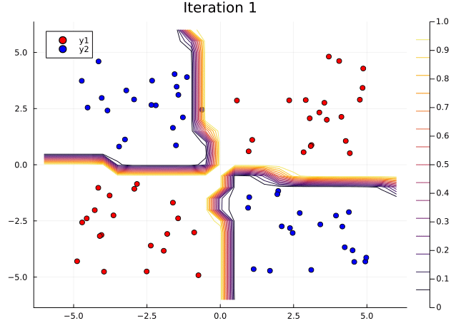

```julia
# Number of iterations to plot.
n_end = 500

anim = @gif for i in 1:n_end
    plot_data()
    Z = [nn_forward(Float32[x1, x2], theta[i, :])[1] for x1 in x1_range, x2 in x2_range]
    contour!(x1_range, x2_range, Z; title="Iteration $i", clim=(0, 1))
end every 5
```

This has been an introduction to the applications of Turing and Flux in defining Bayesian neural networks.

Back to top